# bank marketing

## 目的

- 新たなキャンペーンを行うという設定で、手持ちのデータからペルソナを設定する
- 予測モデルを作成し、ROIを算出する

## データの概要を確認

```r
df <- read.csv("data/bank_marketing_train.csv")
str(df)
```

```
## 'data.frame':    37068 obs. of  21 variables:
##  $ age           : int  56 57 37 40 56 45 59 41 24 25 ...
##  $ job           : Factor w/ 12 levels "admin.","blue-collar",..: 4 8 8 1 8 8 1 2 10 8 ...
##  $ marital       : Factor w/ 4 levels "divorced","married",..: 2 2 2 2 2 2 2 2 3 3 ...
##  $ education     : Factor w/ 8 levels "basic.4y","basic.6y",..: 1 4 4 2 4 3 6 8 6 4 ...
##  $ default       : Factor w/ 3 levels "no","unknown",..: 1 2 1 1 1 2 1 2 1 1 ...
##  $ housing       : Factor w/ 3 levels "no","unknown",..: 1 1 3 1 1 1 1 1 3 3 ...
##  $ loan          : Factor w/ 3 levels "no","unknown",..: 1 1 1 1 3 1 1 1 1 1 ...
##  $ contact       : Factor w/ 2 levels "cellular","telephone": 2 2 2 2 2 2 2 2 2 2 ...
##  $ month         : Factor w/ 9 levels "apr","aug","dec",..: 7 7 7 7 7 7 7 7 7 7 ...
##  $ day_of_week   : Factor w/ 5 levels "fri","mon","thu",..: 2 2 2 2 2 2 2 2 2 2 ...
##  $ duration      : int  261 149 226 151 307 198 139 217 380 50 ...
##  $ campaign      : int  1 1 1 1 1 1 1 1 1 1 ...
##  $ pdays         : int  999 999 999 999 999 999 999 999 999 999 ...
##  $ previous      : int  0 0 0 0 0 0 0 0 0 0 ...
##  $ poutcome      : Factor w/ 3 levels "failure","nonexistent",..: 2 2 2 2 2 2 2 2 2 2 ...
##  $ emp.var.rate  : num  1.1 1.1 1.1 1.1 1.1 1.1 1.1 1.1 1.1 1.1 ...
##  $ cons.price.idx: num  94 94 94 94 94 ...
##  $ cons.conf.idx : num  -36.4 -36.4 -36.4 -36.4 -36.4 -36.4 -36.4 -36.4 -36.4 -36.4 ...
##  $ euribor3m     : num  4.86 4.86 4.86 4.86 4.86 ...
##  $ nr.employed   : num  5191 5191 5191 5191 5191 ...
##  $ y             : Factor w/ 2 levels "no","yes": 1 1 1 1 1 1 1 1 1 1 ...
```

```r
summary(df)
```

```
##       age                  job           marital
##  Min.   :18.00   admin.      :9153   divorced: 4197
##  1st Qu.:32.00   blue-collar :9005   married :22736
##  Median :38.00   technician  :6152   single  :10063
##  Mean   :39.65   services    :3783   unknown :   72
##  3rd Qu.:47.00   management  :2637
##  Max.   :95.00   entrepreneur:1390
##                  (Other)     :4948
##                education        default         housing
##  university.degree  :10541   no     :28565   no     :16855
##  high.school        : 8625   unknown: 8500   unknown:  885
##  basic.9y           : 5787   yes    :    3   yes    :19328
##  professional.course: 4703
##  basic.4y           : 3756
##  basic.6y           : 2206
##  (Other)            : 1450
##       loan            contact          month       day_of_week
##  no     :30518   cellular :22648   may    :13557   fri:7067
##  unknown:  885   telephone:14420   jul    : 6814   mon:7663
##  yes    : 5665                     aug    : 5175   thu:7749
##                                    jun    : 5089   tue:7220
##                                    nov    : 3616   wed:7369
##                                    apr    : 2458
##                                    (Other):  359
##     duration       campaign          pdays          previous
##  Min.   :   0   Min.   : 1.000   Min.   :  0.0   Min.   :0.0000
##  1st Qu.:  99   1st Qu.: 1.000   1st Qu.:999.0   1st Qu.:0.0000
##  Median : 175   Median : 2.000   Median :999.0   Median :0.0000
##  Mean   : 255   Mean   : 2.647   Mean   :989.6   Mean   :0.1002
##  3rd Qu.: 314   3rd Qu.: 3.000   3rd Qu.:999.0   3rd Qu.:0.0000
##  Max.   :4918   Max.   :56.000   Max.   :999.0   Max.   :4.0000
##
##         poutcome      emp.var.rate     cons.price.idx  cons.conf.idx
##  failure    : 3185   Min.   :-2.9000   Min.   :92.47   Min.   :-50.00
##  nonexistent:33549   1st Qu.:-1.8000   1st Qu.:93.08   1st Qu.:-42.70
##  success    :  334   Median : 1.1000   Median :93.92   Median :-42.00
##                      Mean   : 0.3531   Mean   :93.61   Mean   :-41.11
##                      3rd Qu.: 1.4000   3rd Qu.:93.99   3rd Qu.:-36.40
##                      Max.   : 1.4000   Max.   :94.47   Max.   :-33.60
##
##    euribor3m      nr.employed     y
##  Min.   :1.029   Min.   :5076   no :34321
##  1st Qu.:1.663   1st Qu.:5099   yes: 2747
##  Median :4.858   Median :5196
##  Mean   :3.935   Mean   :5184
##  3rd Qu.:4.962   3rd Qu.:5228
##  Max.   :5.045   Max.   :5228
##
```

## データ準備

### yの確認と加工

```r
y_table <- table(df$y)
print(y_table)
```

```
##
##    no   yes
## 34321  2747
```

```r
no_rate <- y_table[1]/y_table[2] #yesに対するnoの割合
print(paste("no rate:",no_rate[[1]]))
```

```
## [1] "no rate: 12.4939934473972"
```

```r
df$y <- ifelse(df$y == "yes", 1, 0)
```

### 学習データとテストデータの分割

- データの分割は、yのyesとnoの割合が同等となるように行う。

```r
set.seed(1234)
yes_idx <- which(df$y == 1)
no_idx <- which(df$y == 0)

train_rate <- 0.7
train_idx <- c(sample(yes_idx, size=length(yes_idx)*train_rate),
                  sample(no_idx, size=length(no_idx)*train_rate))
train <- df[train_idx,]
test <- df[-train_idx,]

train_org <- train
test_org <- test

print(paste("train size:", nrow(train)))
```

```
## [1] "train size: 25946"
```

```r
print(paste("test size:", nrow(test)))
```

```
## [1] "test size: 11122"
```

```r
#この後の可視化で使いやすいよう、trainに対しyesとnoに分けたデータも保持しておく
train_yes <- train[train$y == 1, ]
train_no <- train[train$y == 0, ]

test_yes <- test[test$y == 1, ]
test_no <- test[test$y == 0, ]

#yesに対するnoの割合
print(paste("train's no rate:", nrow(train_no)/nrow(train_yes)))
```

```
## [1] "train's no rate: 12.4994797086368"
```

```r
print(paste("test's no rate:", nrow(test_no)/nrow(test_yes)))
```

```
## [1] "test's no rate: 12.4812121212121"
```

```r
#不要なので削除しておく
rm(test_yes)
rm(test_no)
```

## データを確認する

### 欠損の確認

```r
sapply(train, function(x) any(is.na(train$x)))
```

```
##            age            job        marital      education        default
##          FALSE          FALSE          FALSE          FALSE          FALSE
##        housing           loan        contact          month    day_of_week
##          FALSE          FALSE          FALSE          FALSE          FALSE
##       duration       campaign          pdays       previous       poutcome
##          FALSE          FALSE          FALSE          FALSE          FALSE
##   emp.var.rate cons.price.idx  cons.conf.idx      euribor3m    nr.employed
##          FALSE          FALSE          FALSE          FALSE          FALSE
##              y
##          FALSE
```

NA値は存在しない。

### age

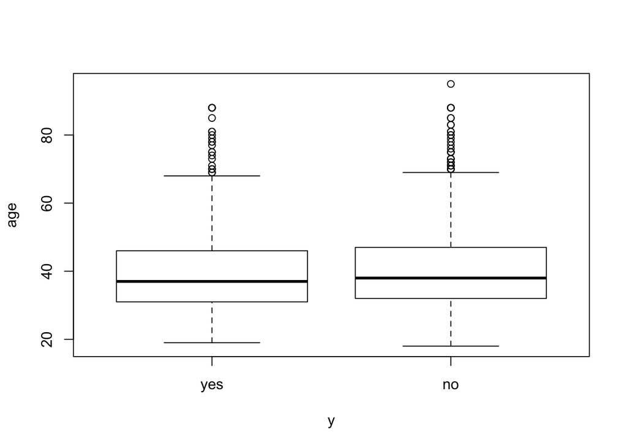

```r
boxplot(train_yes$age, train_no$age, xlab= "y", ylab="age", names=c("yes", "no"))
```

ageによるyes,noの傾向の違いはあまりない模様。

### job

```r
barplot_by_factor <- function(x){
  cross_table <- table(train[, x], train$y)
  cross_table <- cross_table/(cross_table[,1]+cross_table[,2])
  cross_table <- cross_table[order(cross_table[,2]),]
  barplot(t(cross_table), horiz = TRUE, las=1,
          legend.text=c("no", "yes"),
          args.legend = list(x="bottomleft"))
  #return(cross_table)
  return(table(train[, x], train$y))
}
```

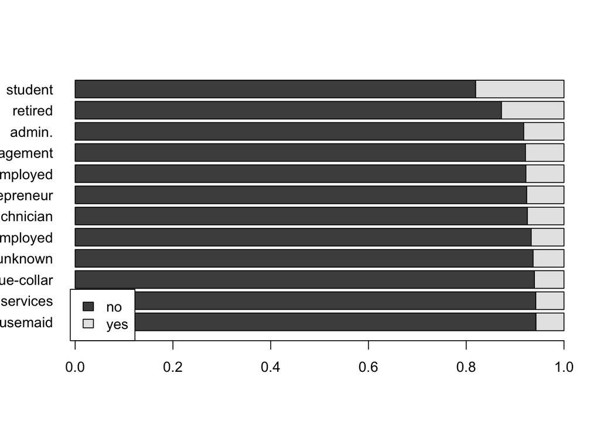

```
##
##                    0    1
##   admin.        5951  534
##   blue-collar   5897  380
##   entrepreneur   908   75
##   housemaid      625   38
##   management    1695  145
##   retired        675   99
##   self-employed  835   60
##   services      2467  151
##   student        272   60
##   technician    3988  323
##   unemployed     533   45
##   unknown        178   12
```

```r
barplot_by_factor("job")
```

studentとretiredは、ほかのjobよりもyesの割合が高くなっている。

## marital

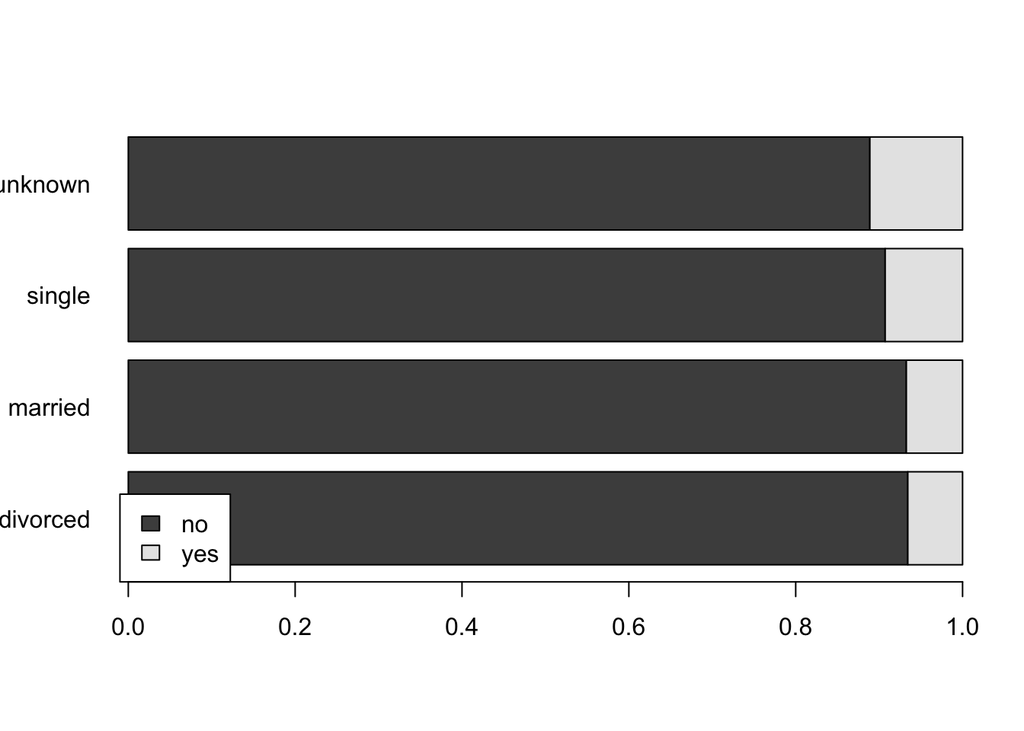

```
##
##                0     1
##   divorced  2734   192
##   married  14933  1079
##   single    6309   645
##   unknown     48     6
```

```r
barplot_by_factor("marital")
```

singleの成約率は比較的高い模様。

## education

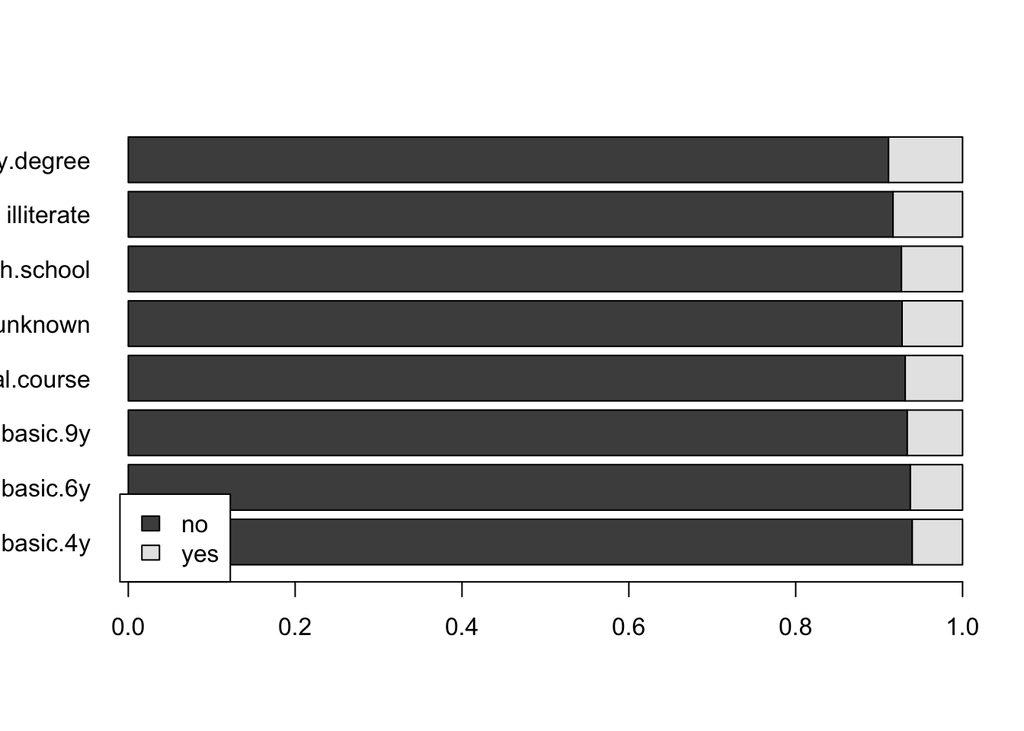

```
##
##                          0    1
##   basic.4y            2462  158
##   basic.6y            1423   95
##   basic.9y            3762  267
##   high.school         5579  441
##   illiterate            11    1
##   professional.course 3103  229
##   university.degree   6788  661
##   unknown              896   70
```

```r
barplot_by_factor("education")
```

## default

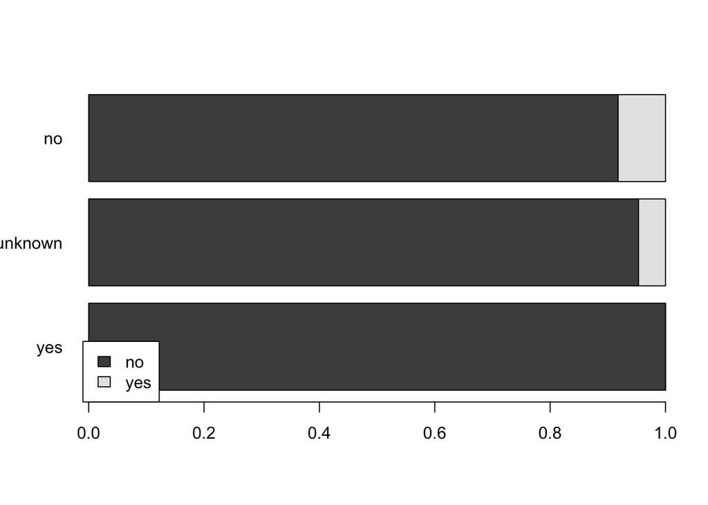

```
##
##               0     1
##   no      18390  1646
##   unknown  5632   276
##   yes         2     0
```

```r
barplot_by_factor("default")
```

## housing

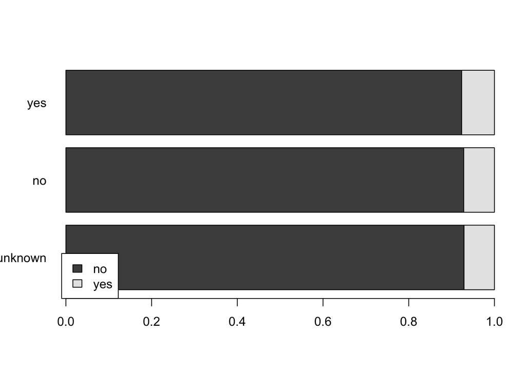

```
##
##               0     1
##   no      10941   843
##   unknown   563    43
##   yes     12520  1036
```

```r
barplot_by_factor("housing")
```

## loan

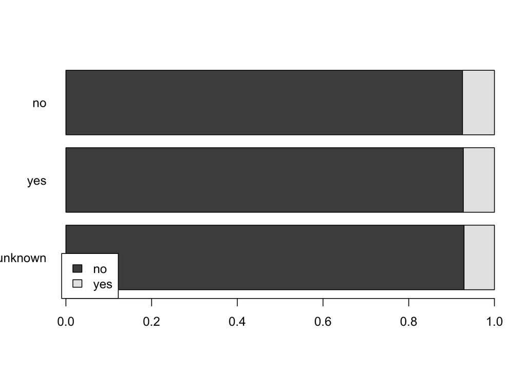

```
##
##               0     1
##   no      19806  1593
##   unknown   563    43
##   yes      3655   286
```

```r
barplot_by_factor("loan")
```

## contact

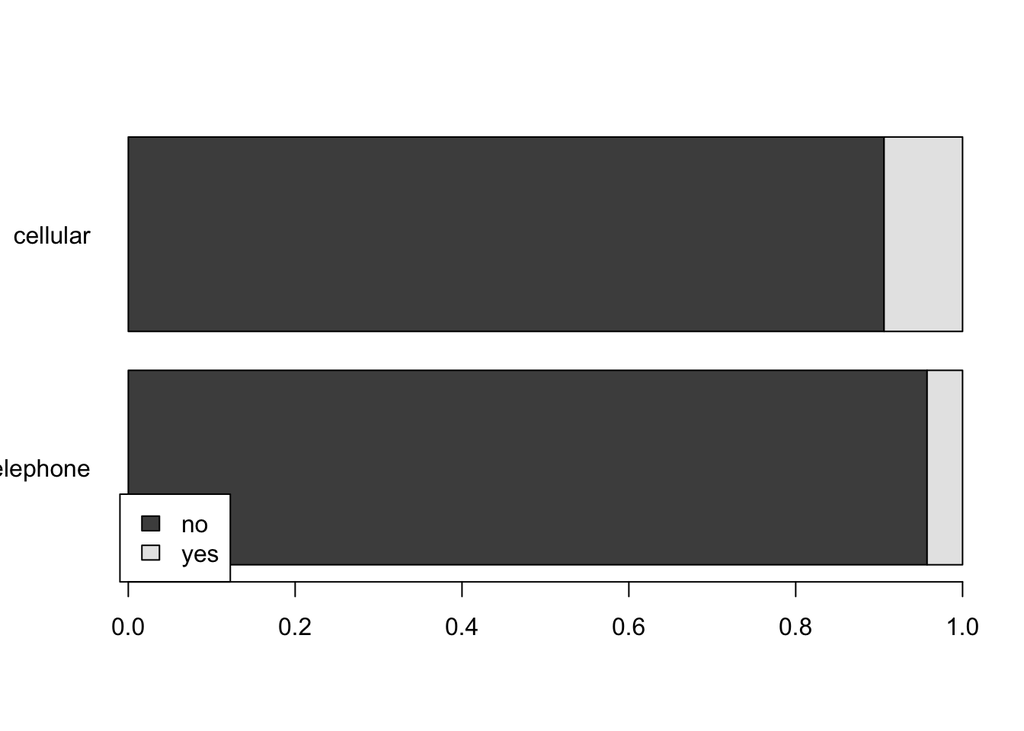

```
##
##                 0     1
##   cellular  14386  1494
##   telephone  9638   428
```

```r
barplot_by_factor("contact")
```

携帯電話でアクセス可能な人の成約率は高い模様。

## month

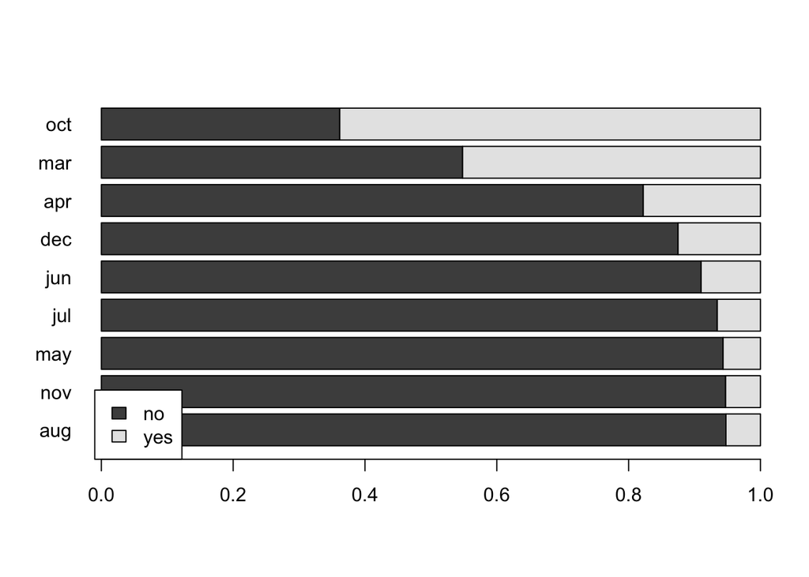

```
##
##          0    1
##   apr 1387  300
##   aug 3459  191
##   dec    7    1
##   jul 4464  313
##   jun 3274  324
##   mar  114   94
##   may 8936  537
##   nov 2366  132
##   oct   17   30
```

```r
barplot_by_factor("month")
```

monthは予測に寄与しそうである。

## day_of_week

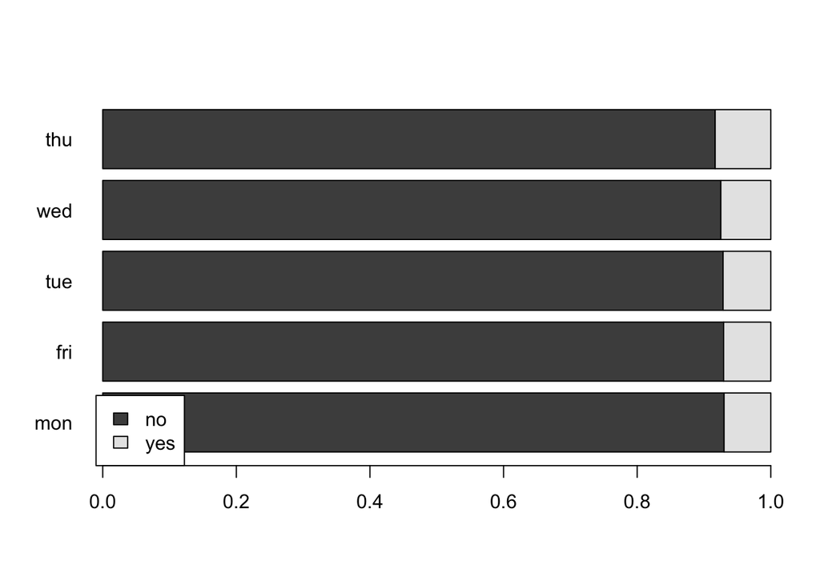

```
##
##          0    1
##   fri 4662  354
##   mon 4999  376
##   thu 4956  450
##   tue 4669  359
##   wed 4738  383
```

```r
barplot_by_factor("day_of_week")
```

## poutcome

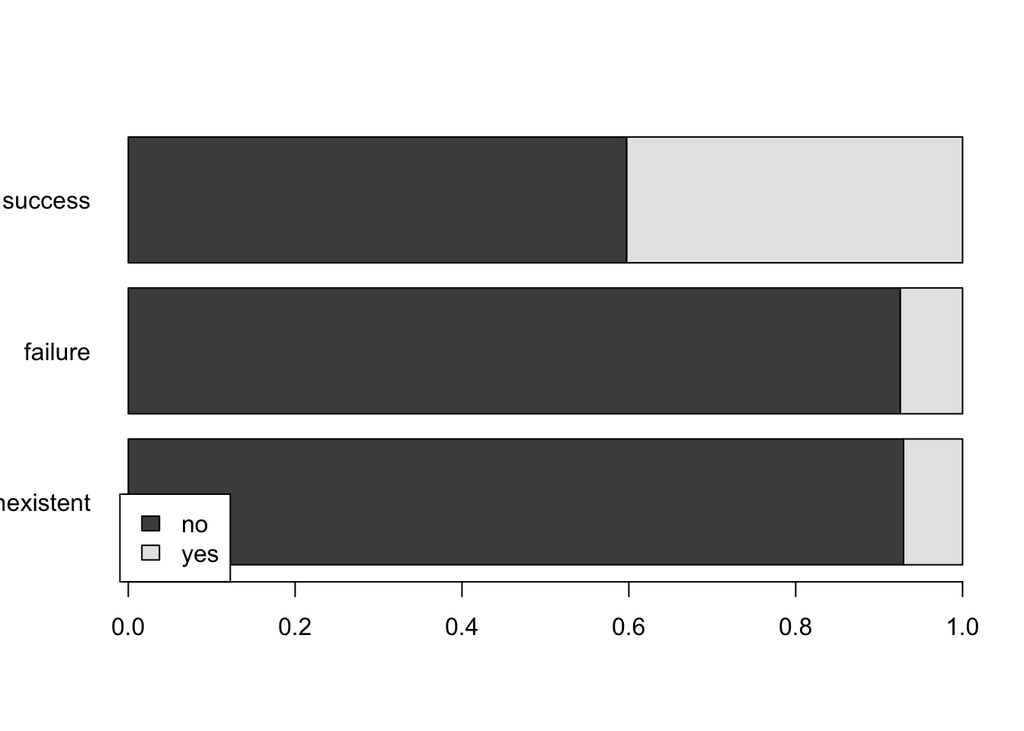

```
##
##                   0     1
##   failure      2047   165
##   nonexistent 21836  1662
##   success       141    95
```

```r
barplot_by_factor("poutcome")
```

successは、予測にかなり寄与しそう。

### pdays

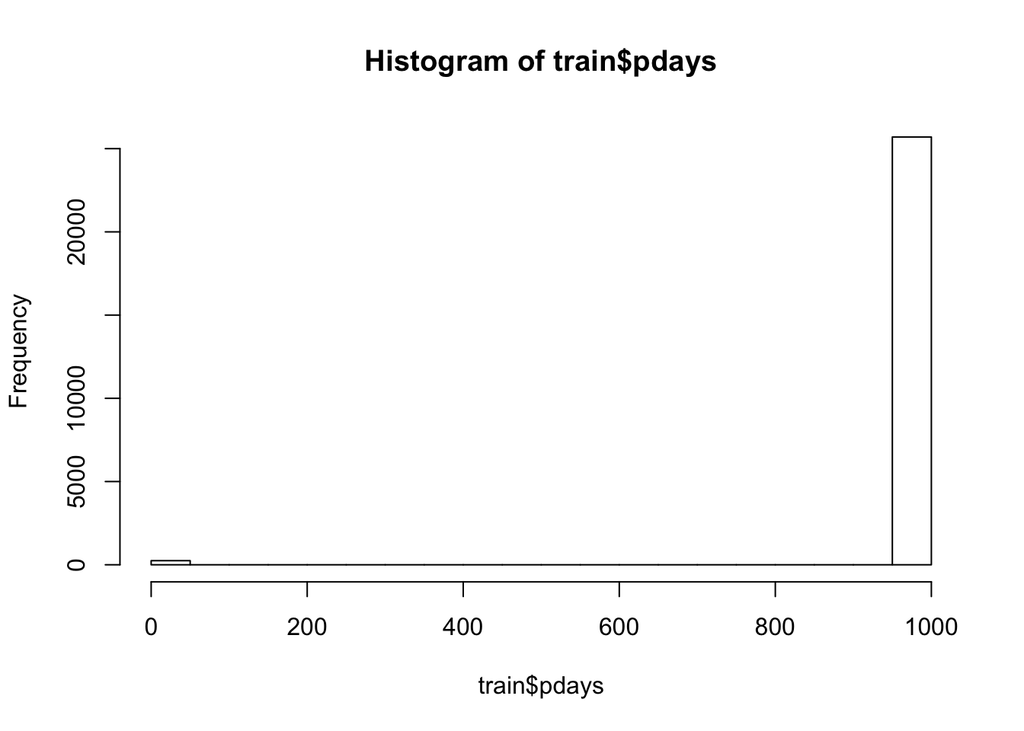

```r
hist(train$pdays)
```

### pdays

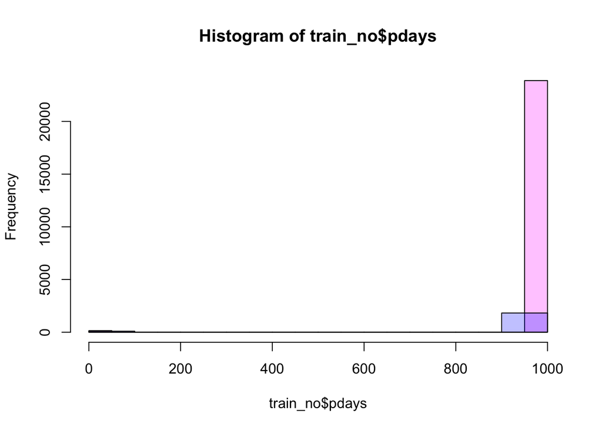

```r
hist(train_no$pdays, col="#ff00ff40")
hist(train_yes$pdays,col="#0000ff40", add=TRUE)
```

### emp.var.rate

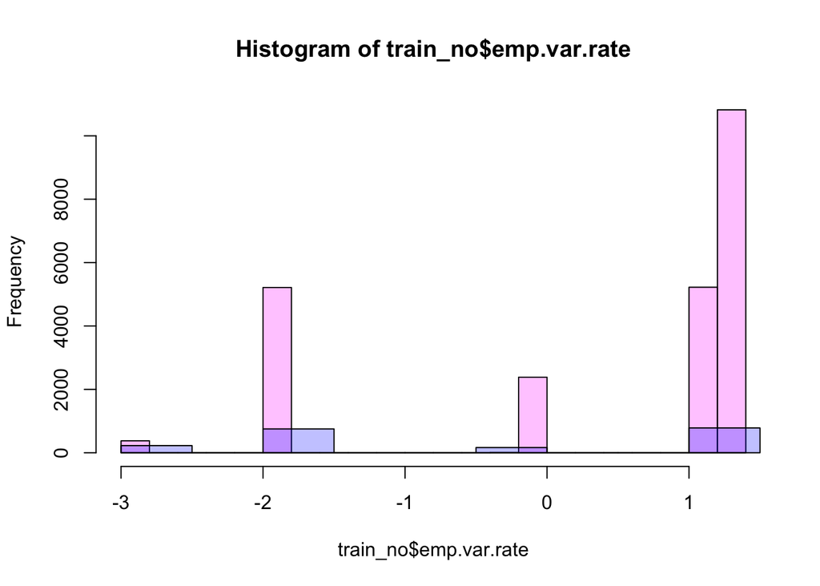

```r
hist(train_no$emp.var.rate, col="#ff00ff40")
hist(train_yes$emp.var.rate,col="#0000ff40", add=TRUE)
```

```r
emp_yes <- table(train_yes$emp.var.rate)
print("yes")
```

```
## [1] "yes"
```

```r
emp_yes
```

```
##
## -2.9 -1.8 -0.2 -0.1  1.1  1.4
##  225  752    1  162  179  603
```

```r
emp_no <- table(train_no$emp.var.rate)
print("no")
```

```
## [1] "no"
```

```r
emp_no
```

```
##
##  -2.9  -1.8  -0.2  -0.1   1.1   1.4
##   376  5214     7  2383  5223 10821
```

```r
print("yes/no")
```

```
## [1] "yes/no"
```

```r
emp_yes/emp_no
```

```
##
##       -2.9       -1.8       -0.2       -0.1        1.1        1.4
## 0.59840426 0.14422708 0.14285714 0.06798154 0.03427149 0.05572498
```

### cons.price.idx

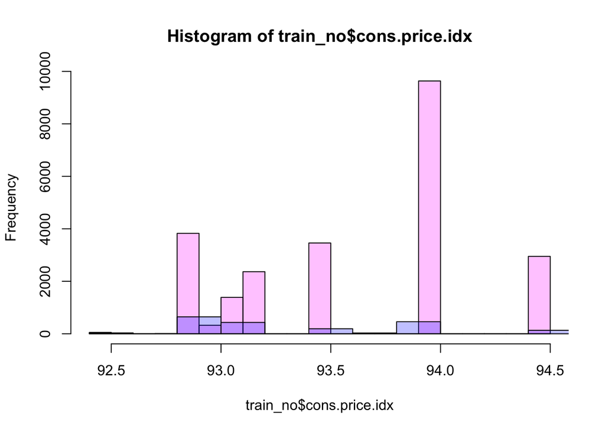

```r
hist(train_no$cons.price.idx, col="#ff00ff40")
hist(train_yes$cons.price.idx,col="#0000ff40", add=TRUE)
```

### cons.price.idx

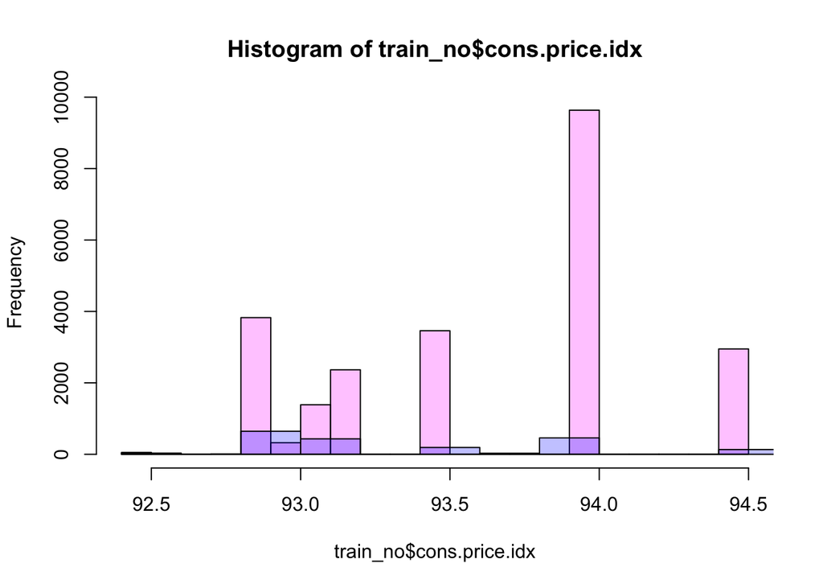

```r
hist(train_no$cons.price.idx, col="#ff00ff40")
hist(train_yes$cons.price.idx,col="#0000ff40", add=TRUE)
```

### cons.conf.idx

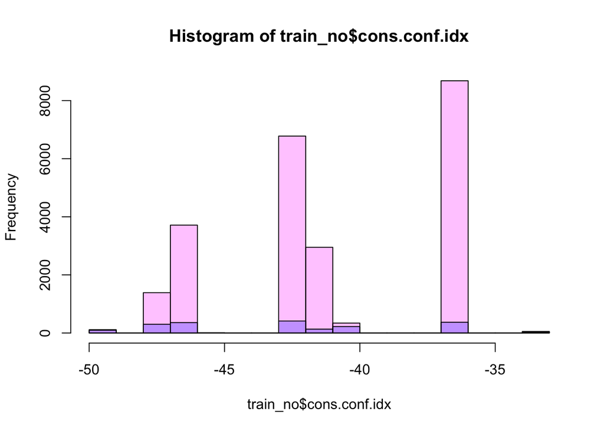

```r
hist(train_no$cons.conf.idx, col="#ff00ff40")
hist(train_yes$cons.conf.idx,col="#0000ff40", add=TRUE)
```

### euribor3m

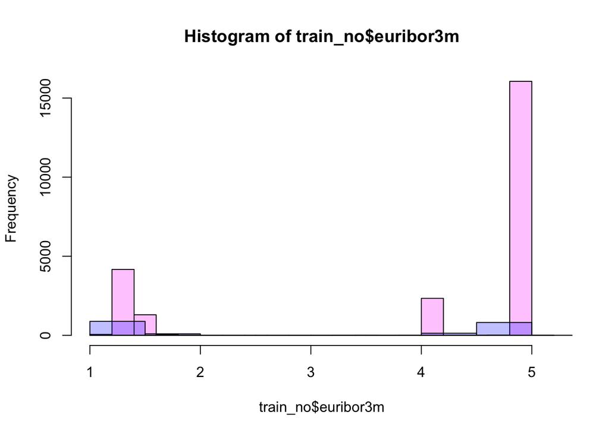

```r
hist(train_no$euribor3m, col="#ff00ff40")
hist(train_yes$euribor3m,col="#0000ff40", add=TRUE)
```

### nr.employed

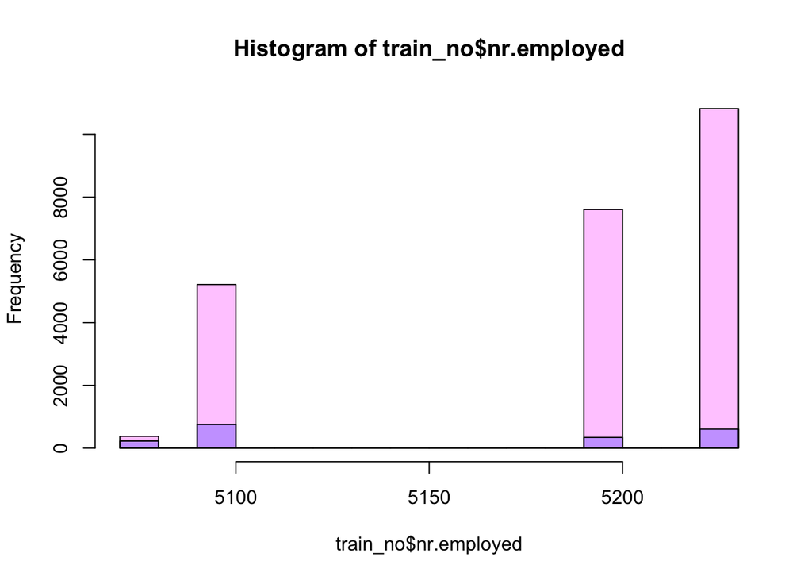

```r
hist(train_no$nr.employed, col="#ff00ff40")
hist(train_yes$nr.employed,col="#0000ff40", add=TRUE)
```

## 特徴量の作成

- yに寄与しそうなファクタは抽出して新たなカラムにする
- unknownは解釈が難しいので、存在するカラムは同様に分割
- （後述のロジスティック回帰を繰り返す中で見つけた特徴もある）

```r
make_new_feature <- function(data){
  #job
  data["is_student"] <- ifelse(data["job"] == "student", 1, 0)
  data["is_retired"] <- ifelse(data["job"] == "retired", 1, 0)

  #marital
  data["is_single"] <- ifelse(data["marital"] == "single", 1, 0)

  #education
  data["education_high"] <- ifelse( data["education"] == "university.degree", 1, 0)
  data[data["education"] == "high.school", "education_high"] <- 1
  data[data["education"] == "professional.course", "education_high"] <- 1

  #default
  data["default_no"] <- ifelse(data["default"] == "no", 1, 0)

  #housing
  data["housing_no"] <- ifelse(data["housing"] == "no", 1, 0)

  #loan
  data["loan_yes"] <- ifelse(data["loan"] == "yes", 1, 0)

  #poutcome
  data["poutcome_success"] <- ifelse(data["poutcome"] == "success", 1, 0)

  #month
  #monthmar  < 2e-16 ***
  #monthoct 4.17e-11 ***
  #monthaug 3.94e-09 ***
  #monthnov 7.06e-07 ***
  #monthjun 2.15e-07 ***
  #monthjul 1.46e-09 ***
  #monthdec 1.28e-06 ***
  data["monthmar"] <- ifelse(data["month"] == "mar", 1, 0)
  data["monthoct"] <- ifelse(data["month"] == "oct", 1, 0)
  data["monthaug"] <- ifelse(data["month"] == "aug", 1, 0)
  data["monthnov"] <- ifelse(data["month"] == "nov", 1, 0)
  data["monthjun"] <- ifelse(data["month"] == "jun", 1, 0)
  data["monthjul"] <- ifelse(data["month"] == "jul", 1, 0)
  data["monthdec"] <- ifelse(data["month"] == "dec", 1, 0)
  data["monthmay"] <- ifelse(data["month"] == "may", 1, 0)

  return(data)
}

train <- make_new_feature(train)
```

## モデル作成

まずあまり考えずロジスティック回帰する

```r
model0 <- glm(y~., data=train, family="binomial")
summary(model0)
```

```
##
## Call:
## glm(formula = y ~ ., family = "binomial", data = train)
##
## Deviance Residuals:
##     Min       1Q   Median       3Q      Max
## -5.7164  -0.2563  -0.1674  -0.1194   3.3186
##
## Coefficients: (18 not defined because of singularities)
##                                Estimate Std. Error z value Pr(>|z|)
## (Intercept)                  -1.518e+04  6.202e+03  -2.447 0.014411 *
## age                          -8.615e-04  3.749e-03  -0.230 0.818274
## jobblue-collar               -1.515e-01  1.123e-01  -1.348 0.177527
## jobentrepreneur              -2.332e-02  1.670e-01  -0.140 0.888929
## jobhousemaid                  1.316e-02  2.271e-01   0.058 0.953782
## jobmanagement                -3.553e-03  1.250e-01  -0.028 0.977323
## jobretired                    6.461e-01  1.706e-01   3.787 0.000153 ***
## jobself-employed             -5.450e-01  1.881e-01  -2.897 0.003769 **
## jobservices                  -2.215e-01  1.249e-01  -1.773 0.076292 .
## jobstudent                    4.144e-01  1.995e-01   2.077 0.037797 *
## jobtechnician                 1.875e-02  1.039e-01   0.180 0.856822
## jobunemployed                 1.399e-01  2.107e-01   0.664 0.506800
## jobunknown                    2.100e-02  4.186e-01   0.050 0.959987
## maritalmarried               -1.868e-02  1.026e-01  -0.182 0.855551
## maritalsingle                 1.055e-01  1.149e-01   0.919 0.358258
## maritalunknown                1.120e-01  5.563e-01   0.201 0.840368
## educationbasic.6y             1.724e-01  1.723e-01   1.001 0.316761
## educationbasic.9y             1.631e-01  1.361e-01   1.199 0.230715
## educationhigh.school          1.991e-01  1.391e-01   1.432 0.152223
## educationilliterate          -5.932e-01  1.326e+00  -0.447 0.654592
## educationprofessional.course  1.804e-01  1.557e-01   1.158 0.246800
## educationuniversity.degree    3.706e-01  1.407e-01   2.634 0.008430 **
## educationunknown              2.194e-01  1.950e-01   1.126 0.260315
## defaultunknown               -2.563e-01  8.766e-02  -2.924 0.003454 **
## defaultyes                   -7.331e+00  1.423e+02  -0.052 0.958915
## housingunknown                1.157e-01  2.050e-01   0.564 0.572466
## housingyes                   -3.330e-03  6.141e-02  -0.054 0.956753
## loanunknown                          NA         NA      NA       NA
## loanyes                      -2.958e-02  8.484e-02  -0.349 0.727400
## contacttelephone             -2.925e-01  1.425e-01  -2.053 0.040048 *
```

[output cut: 34 more lines]

```
## monthnov                             NA         NA      NA       NA
## monthjun                             NA         NA      NA       NA
## monthjul                             NA         NA      NA       NA
## monthdec                             NA         NA      NA       NA
## monthmay                             NA         NA      NA       NA
## ---
## Signif. codes:  0 '***' 0.001 '**' 0.01 '*' 0.05 '.' 0.1 ' ' 1
##
## (Dispersion parameter for binomial family taken to be 1)
##
##     Null deviance: 13703  on 25945  degrees of freedom
## Residual deviance:  8266  on 25895  degrees of freedom
## AIC: 8368
##
## Number of Fisher Scoring iterations: 10
```

```r
AIC(model0)
```

```
## [1] 8367.984
```

未来のデータdurationとcampaignを外してロジスティック回帰する  
(未来のデータ(特にduration)が含まれると精度は高くなることが分かる)

```r
model1 <- glm(y~.-duration-campaign,
               data=train, family="binomial")
summary(model1)
```

```
##
## Call:
## glm(formula = y ~ . - duration - campaign, family = "binomial",
##     data = train)
##
## Deviance Residuals:
##     Min       1Q   Median       3Q      Max
## -1.7804  -0.3737  -0.3152  -0.2650   2.8186
##
## Coefficients: (18 not defined because of singularities)
##                                Estimate Std. Error z value Pr(>|z|)
## (Intercept)                  -8.607e+03  5.205e+03  -1.654 0.098214 .
## age                          -1.417e-03  3.135e-03  -0.452 0.651239
## jobblue-collar               -7.073e-02  9.280e-02  -0.762 0.445937
## jobentrepreneur               8.053e-02  1.367e-01   0.589 0.555848
## jobhousemaid                 -7.108e-02  1.884e-01  -0.377 0.705975
## jobmanagement                 4.479e-03  1.053e-01   0.043 0.966081
## jobretired                    5.095e-01  1.456e-01   3.500 0.000465 ***
## jobself-employed             -2.192e-01  1.509e-01  -1.452 0.146454
## jobservices                  -1.938e-01  1.045e-01  -1.854 0.063760 .
## jobstudent                    3.234e-01  1.700e-01   1.902 0.057151 .
## jobtechnician                 4.139e-02  8.648e-02   0.479 0.632205
## jobunemployed                 5.465e-03  1.736e-01   0.031 0.974883
## jobunknown                   -8.059e-03  3.271e-01  -0.025 0.980346
## maritalmarried                5.987e-02  8.575e-02   0.698 0.485030
## maritalsingle                 1.724e-01  9.577e-02   1.801 0.071781 .
## maritalunknown                4.235e-01  4.657e-01   0.909 0.363143
## educationbasic.6y             1.474e-01  1.416e-01   1.041 0.297992
## educationbasic.9y             1.345e-01  1.124e-01   1.197 0.231477
## educationhigh.school          1.368e-01  1.156e-01   1.184 0.236513
## educationilliterate           2.315e-01  1.085e+00   0.213 0.831051
## educationprofessional.course  1.197e-02  1.295e-01   0.092 0.926329
## educationuniversity.degree    2.105e-01  1.164e-01   1.808 0.070674 .
## educationunknown              1.580e-01  1.618e-01   0.976 0.328836
## defaultunknown               -2.160e-01  7.200e-02  -3.001 0.002694 **
## defaultyes                   -8.748e+00  1.522e+02  -0.057 0.954162
## housingunknown               -4.857e-02  1.726e-01  -0.281 0.778456
## housingyes                   -4.331e-02  5.094e-02  -0.850 0.395184
## loanunknown                          NA         NA      NA       NA
## loanyes                      -2.914e-02  6.996e-02  -0.416 0.677058
```

[output cut: 33 more lines]

```
## monthnov                             NA         NA      NA       NA
## monthjun                             NA         NA      NA       NA
## monthjul                             NA         NA      NA       NA
## monthdec                             NA         NA      NA       NA
## monthmay                             NA         NA      NA       NA
## ---
## Signif. codes:  0 '***' 0.001 '**' 0.01 '*' 0.05 '.' 0.1 ' ' 1
##
## (Dispersion parameter for binomial family taken to be 1)
##
##     Null deviance: 13703  on 25945  degrees of freedom
## Residual deviance: 12239  on 25897  degrees of freedom
## AIC: 12337
##
## Number of Fisher Scoring iterations: 10
```

```r
AIC(model1)
```

```
## [1] 12336.72
```

新たに作成した特徴量の、元の特徴量は除外してモデルを作成

```r
model2 <- glm(y~.-duration-campaign-job-marital-education
              -default-housing-loan-poutcome,
               data=train, family="binomial")
summary(model2)
```

```
##
## Call:
## glm(formula = y ~ . - duration - campaign - job - marital - education -
##     default - housing - loan - poutcome, family = "binomial",
##     data = train)
##
## Deviance Residuals:
##     Min       1Q   Median       3Q      Max
## -1.7664  -0.3726  -0.3170  -0.2662   2.8238
##
## Coefficients: (9 not defined because of singularities)
##                    Estimate Std. Error z value Pr(>|z|)
## (Intercept)      -8.850e+03  5.204e+03  -1.701 0.088997 .
## age              -1.583e-03  3.060e-03  -0.517 0.604867
## contacttelephone -5.459e-01  1.178e-01  -4.634 3.59e-06 ***
## monthaug          7.860e+01  4.665e+01   1.685 0.092037 .
## monthdec          8.511e+01  4.967e+01   1.713 0.086655 .
## monthjul          3.006e+01  1.781e+01   1.688 0.091457 .
## monthjun         -2.074e+01  1.216e+01  -1.705 0.088164 .
## monthmar          2.148e+01  1.185e+01   1.813 0.069884 .
## monthmay          1.681e+01  1.035e+01   1.624 0.104272
## monthnov          4.815e+01  2.895e+01   1.663 0.096299 .
## monthoct         -2.486e+00  3.038e+00  -0.818 0.413175
## day_of_weekmon   -1.164e-01  8.128e-02  -1.432 0.152206
## day_of_weekthu    1.346e-01  7.767e-02   1.733 0.083087 .
## day_of_weektue   -5.745e-03  8.292e-02  -0.069 0.944761
## day_of_weekwed    1.294e-01  8.094e-02   1.598 0.109977
## pdays            -1.632e-03  7.620e-04  -2.142 0.032211 *
## previous         -4.559e-01  8.425e-02  -5.411 6.27e-08 ***
## emp.var.rate     -3.269e+01  1.888e+01  -1.731 0.083408 .
## cons.price.idx    9.415e+01  5.535e+01   1.701 0.088961 .
## cons.conf.idx    -6.206e-01  3.957e-01  -1.569 0.116747
## euribor3m        -9.324e-01  7.112e-01  -1.311 0.189842
## nr.employed              NA         NA      NA       NA
## is_student        3.624e-01  1.636e-01   2.215 0.026751 *
## is_retired        5.158e-01  1.350e-01   3.819 0.000134 ***
## is_single         1.303e-01  6.036e-02   2.159 0.030871 *
## education_high    6.671e-02  5.631e-02   1.185 0.236124
## default_no        2.311e-01  7.151e-02   3.232 0.001229 **
## housing_no        4.317e-02  5.038e-02   0.857 0.391544
## loan_yes         -2.577e-02  6.970e-02  -0.370 0.711607
## poutcome_success  2.064e-01  7.556e-01   0.273 0.784710
## monthmar                 NA         NA      NA       NA
## monthoct                 NA         NA      NA       NA
## monthaug                 NA         NA      NA       NA
## monthnov                 NA         NA      NA       NA
## monthjun                 NA         NA      NA       NA
## monthjul                 NA         NA      NA       NA
## monthdec                 NA         NA      NA       NA
## monthmay                 NA         NA      NA       NA
## ---
## Signif. codes:  0 '***' 0.001 '**' 0.01 '*' 0.05 '.' 0.1 ' ' 1
##
## (Dispersion parameter for binomial family taken to be 1)
##
##     Null deviance: 13703  on 25945  degrees of freedom
## Residual deviance: 12261  on 25917  degrees of freedom
## AIC: 12319
##
## Number of Fisher Scoring iterations: 6
```

```r
AIC(model2)
```

```
## [1] 12318.99
```

step関数で最適化する

```r
op_model2 <- step(model2)
```

```
## Start:  AIC=12318.99
## y ~ (age + job + marital + education + default + housing + loan +
##     contact + month + day_of_week + duration + campaign + pdays +
##     previous + poutcome + emp.var.rate + cons.price.idx + cons.conf.idx +
##     euribor3m + nr.employed + is_student + is_retired + is_single +
##     education_high + default_no + housing_no + loan_yes + poutcome_success +
##     monthmar + monthoct + monthaug + monthnov + monthjun + monthjul +
##     monthdec + monthmay) - duration - campaign - job - marital -
##     education - default - housing - loan - poutcome
##
##
## Step:  AIC=12318.99
## y ~ age + contact + month + day_of_week + pdays + previous +
##     emp.var.rate + cons.price.idx + cons.conf.idx + euribor3m +
##     nr.employed + is_student + is_retired + is_single + education_high +
##     default_no + housing_no + loan_yes + poutcome_success + monthmar +
##     monthoct + monthaug + monthnov + monthjun + monthjul + monthdec
##
##
## Step:  AIC=12318.99
## y ~ age + contact + month + day_of_week + pdays + previous +
##     emp.var.rate + cons.price.idx + cons.conf.idx + euribor3m +
##     nr.employed + is_student + is_retired + is_single + education_high +
##     default_no + housing_no + loan_yes + poutcome_success + monthmar +
##     monthoct + monthaug + monthnov + monthjun + monthjul
##
##
## Step:  AIC=12318.99
## y ~ age + contact + month + day_of_week + pdays + previous +
##     emp.var.rate + cons.price.idx + cons.conf.idx + euribor3m +
##     nr.employed + is_student + is_retired + is_single + education_high +
##     default_no + housing_no + loan_yes + poutcome_success + monthmar +
##     monthoct + monthaug + monthnov + monthjun
##
##
## Step:  AIC=12318.99
## y ~ age + contact + month + day_of_week + pdays + previous +
##     emp.var.rate + cons.price.idx + cons.conf.idx + euribor3m +
##     nr.employed + is_student + is_retired + is_single + education_high +
##     default_no + housing_no + loan_yes + poutcome_success + monthmar +
```

[output cut: 199 more lines]

```
##     cons.price.idx + is_student + is_retired + is_single + default_no
##
##                  Df Deviance   AIC
## <none>                 12266 12310
## - is_student      1    12271 12313
## - is_single       1    12274 12316
## - day_of_week     4    12282 12318
## - default_no      1    12280 12322
## - is_retired      1    12280 12322
## - contact         1    12295 12337
## - previous        1    12300 12342
## - cons.price.idx  1    12302 12344
## - emp.var.rate    1    12312 12354
## - pdays           1    12380 12422
## - month           8    12630 12658
```

```r
summary(op_model2)
```

```
##
## Call:
## glm(formula = y ~ contact + month + day_of_week + pdays + previous +
##     emp.var.rate + cons.price.idx + is_student + is_retired +
##     is_single + default_no, family = "binomial", data = train)
##
## Deviance Residuals:
##     Min       1Q   Median       3Q      Max
## -1.8372  -0.3740  -0.3195  -0.2667   2.7580
##
## Coefficients:
##                    Estimate Std. Error z value Pr(>|z|)
## (Intercept)      -7.741e+02  1.300e+02  -5.957 2.57e-09 ***
## contacttelephone -5.799e-01  1.146e-01  -5.059 4.22e-07 ***
## monthaug          6.170e+00  1.054e+00   5.857 4.72e-09 ***
## monthdec          8.050e+00  1.660e+00   4.850 1.23e-06 ***
## monthjul          2.429e+00  4.042e-01   6.010 1.86e-09 ***
## monthjun         -1.845e+00  3.605e-01  -5.117 3.10e-07 ***
## monthmar          3.137e+00  3.604e-01   8.703  < 2e-16 ***
## monthmay          7.382e-01  2.445e-01   3.019 0.002538 **
## monthnov          3.275e+00  6.662e-01   4.917 8.81e-07 ***
## monthoct          2.286e+00  3.430e-01   6.666 2.62e-11 ***
## day_of_weekmon   -1.272e-01  8.061e-02  -1.578 0.114676
## day_of_weekthu    1.320e-01  7.760e-02   1.701 0.088968 .
## day_of_weektue   -1.685e-02  8.228e-02  -0.205 0.837743
## day_of_weekwed    1.178e-01  8.038e-02   1.466 0.142641
## pdays            -1.843e-03  1.663e-04 -11.080  < 2e-16 ***
## previous         -4.643e-01  8.338e-02  -5.568 2.58e-08 ***
## emp.var.rate     -3.312e+00  4.872e-01  -6.798 1.06e-11 ***
## cons.price.idx    8.254e+00  1.387e+00   5.952 2.66e-09 ***
## is_student        3.660e-01  1.620e-01   2.260 0.023825 *
## is_retired        4.729e-01  1.221e-01   3.874 0.000107 ***
## is_single         1.562e-01  5.544e-02   2.818 0.004838 **
## default_no        2.524e-01  6.990e-02   3.611 0.000305 ***
## ---
## Signif. codes:  0 '***' 0.001 '**' 0.01 '*' 0.05 '.' 0.1 ' ' 1
##
## (Dispersion parameter for binomial family taken to be 1)
##
##     Null deviance: 13703  on 25945  degrees of freedom
## Residual deviance: 12266  on 25924  degrees of freedom
## AIC: 12310
##
## Number of Fisher Scoring iterations: 6
```

```r
AIC(op_model2)
```

```
## [1] 12310.35
```

得られた結果を基に改めてモデルを構築した。  
day_of_weekは重要度が高くないように見受けられる（可視化の時点でも隔たりがほぼなかった）ため除外。

```r
model3 <- glm(y~contact +
                monthmar+ monthoct+ monthaug+ monthnov+
                monthjun+ monthjul+ monthdec+ monthmay+
                pdays + previous +
                emp.var.rate + cons.price.idx +
                is_student + is_retired +
                is_single + default_no,
              data=train, family="binomial")
summary(model3)
```

```
##
## Call:
## glm(formula = y ~ contact + monthmar + monthoct + monthaug +
##     monthnov + monthjun + monthjul + monthdec + monthmay + pdays +
##     previous + emp.var.rate + cons.price.idx + is_student + is_retired +
##     is_single + default_no, family = "binomial", data = train)
##
## Deviance Residuals:
##     Min       1Q   Median       3Q      Max
## -1.7992  -0.3582  -0.3261  -0.2608   2.7837
##
## Coefficients:
##                    Estimate Std. Error z value Pr(>|z|)
## (Intercept)      -7.758e+02  1.297e+02  -5.982 2.20e-09 ***
## contacttelephone -5.732e-01  1.143e-01  -5.014 5.33e-07 ***
## monthmar          3.125e+00  3.590e-01   8.706  < 2e-16 ***
## monthoct          2.259e+00  3.424e-01   6.598 4.17e-11 ***
## monthaug          6.186e+00  1.051e+00   5.887 3.94e-09 ***
## monthnov          3.295e+00  6.644e-01   4.960 7.06e-07 ***
## monthjun         -1.868e+00  3.602e-01  -5.186 2.15e-07 ***
## monthjul          2.437e+00  4.029e-01   6.049 1.46e-09 ***
## monthdec          8.024e+00  1.657e+00   4.843 1.28e-06 ***
## monthmay          7.372e-01  2.432e-01   3.031 0.002438 **
## pdays            -1.848e-03  1.658e-04 -11.145  < 2e-16 ***
## previous         -4.597e-01  8.329e-02  -5.519 3.41e-08 ***
## emp.var.rate     -3.317e+00  4.863e-01  -6.821 9.02e-12 ***
## cons.price.idx    8.272e+00  1.384e+00   5.977 2.27e-09 ***
## is_student        3.677e-01  1.621e-01   2.269 0.023294 *
## is_retired        4.739e-01  1.218e-01   3.891 9.96e-05 ***
## is_single         1.604e-01  5.542e-02   2.894 0.003806 **
## default_no        2.555e-01  6.986e-02   3.658 0.000254 ***
## ---
## Signif. codes:  0 '***' 0.001 '**' 0.01 '*' 0.05 '.' 0.1 ' ' 1
##
## (Dispersion parameter for binomial family taken to be 1)
##
##     Null deviance: 13703  on 25945  degrees of freedom
## Residual deviance: 12282  on 25928  degrees of freedom
## AIC: 12318
##
## Number of Fisher Scoring iterations: 6
```

```r
AIC(model3)
```

```
## [1] 12317.52
```

```r
exp(model3$coefficients)
```

```
##      (Intercept) contacttelephone         monthmar         monthoct
##     0.000000e+00     5.636978e-01     2.277077e+01     9.574296e+00
##         monthaug         monthnov         monthjun         monthjul
##     4.860904e+02     2.697658e+01     1.543989e-01     1.144144e+01
##         monthdec         monthmay            pdays         previous
##     3.053001e+03     2.090150e+00     9.981541e-01     6.314945e-01
##     emp.var.rate   cons.price.idx       is_student       is_retired
##     3.626623e-02     3.913790e+03     1.444345e+00     1.606225e+00
##        is_single       default_no
##     1.173953e+00     1.291159e+00
```

評価用の関数を定義

```r
#ROI = 成約数*2000 -架電数*500
calc_ROI <- function(conf_mat){
  if(!all(dim(conf_mat) == c(2,2))){
    return(0)
  }
  cv_cnt <- conf_mat[4]
  attack_cnt <- conf_mat[3] + conf_mat[4]
  roi <- cv_cnt*2000 - attack_cnt*500
  return(roi)
}

#予測結果（確率）に対し、1に分類するための閾値を探す
optimize_threshold <- function(model, data, type){
  score <- predict(model, data, type = type)
  #hist(score)

  max_threshold <- 0
  max_ROI <- -Inf
  for(th in c(1:100)/100) {
    ypred_flg <- ifelse(th < score, 1, 0)
    conf_mat <- table(data$y, ypred_flg)
    ROI <- calc_ROI(conf_mat)
    #print(paste(th, ":", ROI), quote = FALSE)
    if(ROI > max_ROI){
      max_ROI <- ROI
      max_threshold <- th
    }
  }
  return(max_threshold)
}
```

閾値をサーチする

```r
optimized_threshold <- optimize_threshold(model3, train, "response")
optimized_threshold
```

```
## [1] 0.2
```

## testデータを使ってモデルを評価する

```r
best_model <- model3 #ロジスティック回帰
print_predict <- function(model, data, type, threshold){
  score <- predict(model, data, type = type)
  ypred_flg <- ifelse(threshold < score, 1, 0)
  conf_mat <- table(data$y, ypred_flg)
  print("confusion matrix")
  print(conf_mat)
  #hist(score)
  print(paste("ROI:", calc_ROI(conf_mat)))
}
```

```r
test <- make_new_feature(test)
print_predict(best_model, test, "response", 0.2)
```

```
## [1] "confusion matrix"
##    ypred_flg
##        0    1
##   0 9930  367
##   1  600  225
## [1] "ROI: 154000"
```

ROIは154000円。ひとまず黒字のため良しとする。

## ペルソナ設定

```r
summary(best_model)
```

```
##
## Call:
## glm(formula = y ~ contact + monthmar + monthoct + monthaug +
##     monthnov + monthjun + monthjul + monthdec + monthmay + pdays +
##     previous + emp.var.rate + cons.price.idx + is_student + is_retired +
##     is_single + default_no, family = "binomial", data = train)
##
## Deviance Residuals:
##     Min       1Q   Median       3Q      Max
## -1.7992  -0.3582  -0.3261  -0.2608   2.7837
##
## Coefficients:
##                    Estimate Std. Error z value Pr(>|z|)
## (Intercept)      -7.758e+02  1.297e+02  -5.982 2.20e-09 ***
## contacttelephone -5.732e-01  1.143e-01  -5.014 5.33e-07 ***
## monthmar          3.125e+00  3.590e-01   8.706  < 2e-16 ***
## monthoct          2.259e+00  3.424e-01   6.598 4.17e-11 ***
## monthaug          6.186e+00  1.051e+00   5.887 3.94e-09 ***
## monthnov          3.295e+00  6.644e-01   4.960 7.06e-07 ***
## monthjun         -1.868e+00  3.602e-01  -5.186 2.15e-07 ***
## monthjul          2.437e+00  4.029e-01   6.049 1.46e-09 ***
## monthdec          8.024e+00  1.657e+00   4.843 1.28e-06 ***
## monthmay          7.372e-01  2.432e-01   3.031 0.002438 **
## pdays            -1.848e-03  1.658e-04 -11.145  < 2e-16 ***
## previous         -4.597e-01  8.329e-02  -5.519 3.41e-08 ***
## emp.var.rate     -3.317e+00  4.863e-01  -6.821 9.02e-12 ***
## cons.price.idx    8.272e+00  1.384e+00   5.977 2.27e-09 ***
## is_student        3.677e-01  1.621e-01   2.269 0.023294 *
## is_retired        4.739e-01  1.218e-01   3.891 9.96e-05 ***
## is_single         1.604e-01  5.542e-02   2.894 0.003806 **
## default_no        2.555e-01  6.986e-02   3.658 0.000254 ***
## ---
## Signif. codes:  0 '***' 0.001 '**' 0.01 '*' 0.05 '.' 0.1 ' ' 1
##
## (Dispersion parameter for binomial family taken to be 1)
##
##     Null deviance: 13703  on 25945  degrees of freedom
## Residual deviance: 12282  on 25928  degrees of freedom
## AIC: 12318
##
## Number of Fisher Scoring iterations: 6
```

```r
exp(best_model$coefficients) #オッズ
```

```
##      (Intercept) contacttelephone         monthmar         monthoct
##     0.000000e+00     5.636978e-01     2.277077e+01     9.574296e+00
##         monthaug         monthnov         monthjun         monthjul
##     4.860904e+02     2.697658e+01     1.543989e-01     1.144144e+01
##         monthdec         monthmay            pdays         previous
##     3.053001e+03     2.090150e+00     9.981541e-01     6.314945e-01
##     emp.var.rate   cons.price.idx       is_student       is_retired
##     3.626623e-02     3.913790e+03     1.444345e+00     1.606225e+00
##        is_single       default_no
##     1.173953e+00     1.291159e+00
```

上記より

- リタイア層
- 滞納がnoな人
- 独身者

解釈しにくかった変数（けど効きそうなもの）